# Home Credit Default Risk

This notebook analyses Home Credit dataset downloaded from [Kaggle](https://www.kaggle.com/competitions/home-credit-default-risk/data).

## Goal

The goal of this project is to develop an accurate predictive model for Home Credit that assesses the risk of default among prospective clients.

## Objectives

To achieve this goal, the following objectives have been established:

1. Download, load and clean the dataset.
2. Conduct exploratory data analysis and visualize data to identify underlying patterns.
3. Perform statistical inference to validate findings.
4. Apply machine learning models to predict the probability of client default.
5. Summarize results and provide actionable recommendations based on the analysis.

## Libraries

```python
import contextlib
import gc
import os
import time
import warnings

import lightgbm as lgb
import matplotlib.pyplot as plt
import numpy as np
import optuna
import pandas as pd
import seaborn as sns
import shap
from category_encoders import TargetEncoder
from joblib import dump
from lightgbm import LGBMClassifier, early_stopping, log_evaluation
from scipy import stats
from scipy.stats import chi2_contingency, mannwhitneyu, shapiro
from sklearn.dummy import DummyClassifier
from sklearn.metrics import (
    auc,
    average_precision_score,
    classification_report,
    confusion_matrix,
    precision_recall_curve,
    roc_auc_score,
    roc_curve,
)
from sklearn.model_selection import cross_val_score, train_test_split
from ydata_profiling import ProfileReport

# Running a custom functions file
%run homecredit_functions.ipynb
```

```python
warnings.filterwarnings("ignore")

pd.set_option("display.float_format", lambda x: "%.3f" % x)

%matplotlib inline
```

```python
from IPython.core.display import HTML

HTML(
    """
<style>
.output_png {
    display: table-cell;
    text-align: center;
    vertical-align: middle;
}
</style>
"""
)
```

```python
plt.rcParams.update(
    {
        "font.family": "Trebuchet MS",
        "axes.titlesize": 10,
        "axes.titlepad": 13,
        "axes.labelsize": 10,
        "xtick.labelsize": 10,
        "ytick.labelsize": 10,
        "legend.fontsize": 9,
        "legend.title_fontsize": 9,
    }
)

custom_palette = [
    "#001219",
    "#005F73",
    "#0A9396",
    "#94D2BD",
    "#E9D8A6",
    "#EE9B00",
    "#CA6702",
    "#BB3E03",
    "#AE2012",
    "#9B2226",
]
```

## Dataset

### Importing Data

```python
df = pd.read_csv(
    r"C:\Users\nacev\OneDrive\turing\datasets\homecredit\application_train.csv"
)
bureau = pd.read_csv(r"C:\Users\nacev\OneDrive\turing\datasets\homecredit\bureau.csv")
bureau_balance = pd.read_csv(
    r"C:\Users\nacev\OneDrive\turing\datasets\homecredit\bureau_balance.csv"
)
cc_balance = pd.read_csv(
    r"C:\Users\nacev\OneDrive\turing\datasets\homecredit\credit_card_balance.csv"
)
installments = pd.read_csv(
    r"C:\Users\nacev\OneDrive\turing\datasets\homecredit\installments_payments.csv"
)
pos_cash = pd.read_csv(
    r"C:\Users\nacev\OneDrive\turing\datasets\homecredit\POS_CASH_balance.csv"
)
previous_application = pd.read_csv(
    r"C:\Users\nacev\OneDrive\turing\datasets\homecredit\previous_application.csv"
)
```

```python
df = downcast(df)
bureau = downcast(bureau)
bureau_balance = downcast(bureau_balance)
cc_balance = downcast(cc_balance)
installments = downcast(installments)
pos_cash = downcast(pos_cash)
previous_application = downcast(previous_application)
```

```python
gc.collect()
```

```
20
```

### Dataset Overview

**application_train:** The main table, split into two files: Train (with TARGET) and Test (without TARGET). Each row represents one loan application, containing static data for all applications.

**bureau:** Contains data on clients' previous credits from other financial institutions reported to the Credit Bureau. For each loan in the sample, there are multiple rows corresponding to the number of credits the client had prior to the application date.

**bureau_balance:** Monthly balances for previous credits reported to the Credit Bureau. Each row represents a month of history for every previous credit.

**POS_CASH_balance:** Monthly balance snapshots of prior POS (point-of-sale) and cash loans with Home Credit. Each row corresponds to a month of history for every previous credit related to loans in the sample.

**credit_card_balance:** Monthly balance snapshots of previous credit cards held with Home Credit. Each row indicates a month of history for every previous credit card related to loans in the sample.

**previous_application:** Records of all previous loan applications for Home Credit from clients with loans in the sample. Each row corresponds to a previous application related to loans in the data sample.

**installments_payments:** Repayment history for previously disbursed credits in Home Credit related to loans in the sample. This table includes one row for every payment made and one row for each missed payment. Each row represents either an installment payment or a missed payment for one previous Home Credit loan.

To familiarize ourselves with the data and identify trends or other insights, Profile Reports will be created.

#### Application

```python
profiledf = ProfileReport(df, minimal=True)
profiledf.to_file("report_df.html")
```

The table has 122 variables and around 307 thousand observations. 24.4% cells are missing.

This table contains loan-related information for clients, including demographic data, loan details, and various flags about personal circumstances. It includes the target variable, indicating whether a client had payment difficulties, and features related to personal characteristics (such as income, family, and employment), loan attributes (amount, annuity, and type), and housing conditions. There are also indicators for asset ownership (car, real estate) and various normalized scores from external data sources. Additionally, the table contains numerous flags regarding phone, email, and address details, as well as features related to the type and condition of the building where the client resides.

Profile report provides some key points to have in mind:

- Missing values are coded as *XNA*.
- *Organization type* has a high cardinality with 58 distinct values.
- Several features have strong correlations with each other, especially among average, mode, and median versions of apartment, basement, land, and living area-related features.
- Many features have a significant percentage of missing values, ranging from around 13% to as high as 70%.
- Several numeric features are highly skewed.
- Some features contain a large percentage of zeros.

#### Bureau / Bureau Balance

```python
profileb = ProfileReport(bureau, title="Bureau Report")
profileb.to_file("report_b.html")
```

```python
profilebb = ProfileReport(bureau_balance, title="Bureau Balance Report")
profilebb.to_file("report_bb.html")
```

Bureau table has 17 variables and around 1.7 million observations, with 13.5% entries missing.

The table contains details about clients' credit history - loan status, currency, and key time-related metrics, such as the duration and overdue status of previous credits. Additionally, the table includes financial metrics related to the current credit amount, outstanding debt, and maximum overdue amounts. It also captures information on credit extensions and annuity payments while classifying the type of credit.

Similarly as in previous table, several fields show high correlations, imbalance and skewness. Also, some have significant missing data and high percentage of zeros.

Bureau Balance table has around 27.3 million entries and only 3 variables with no missing values.

#### Credit Card Balance

```python
profilecc = ProfileReport(cc_balance, minimal=True)
profilecc.to_file("report_cc.html")
```

The Credit Card Balance table has 23 variables and aroun 3.8 million observations, with 6.7% of values missing.

It tracks various financial metrics over time, such as the monthly balance, credit limits, and amounts drawn from ATMs or for purchases. Additionally, it records payments made, amounts receivable, and the status of each credit contract.

Some skewness, missing values are present here. Several features are highly correlated as well. Also, `name_contract_status` is highly imbalanced, since most of the contracts are still active.

#### Installments

```python
profileinst = ProfileReport(installments, minimal=True)
profileinst.to_file("report_inst.html")
```

The Installments table has 8 variables, around 14 million observations and almost none (<0.1%) missing values.

The table provides information on previous credit agreements related to loans in the Home Credit dataset, specifically focusing on the installment payments. It captures details such as the version of the installment calendar, the number of the installment being observed, and the scheduled versus actual payment dates. Additionally, the table records the prescribed installment amounts and the actual payments made by clients.

Almost no issues like those in the other tables are present here, although some of the features are highly correlated with each other.

#### POS Cash

```python
profilepos = ProfileReport(pos_cash, minimal=True)
profilepos.to_file("report_pos.html")
```

The POS Cash table has 8 variables and around 10 million observations, with very little (0.1%) missing values.

`Name_contract_status` is highly imbalanced here as well, one feature is highly skewed.

The table contains information on previous point-of-sale cash loans associated with loans in the Home Credit dataset. It provides insights into the monthly balance relative to the application date, including the term of the previous credit and the remaining installments to be paid. The table also records the contract status during each month and tracks days past due (DPD), both with and without tolerance for low loan amounts.

#### Previous Application

```python
profileprev = ProfileReport(previous_application, minimal=True)
profileprev.to_file("report_prev.html")
```

The Previous Application table has 37 variables and around 1.7 million observations. 18% cells are missing.

The table again deals with highly correlated features, imbalance, and skewness.

The table provides detailed information about past loan applications made by clients in the Home Credit dataset. It includes various aspects of each application, such as the type of contract, requested and granted credit amounts, down payments, and the purpose of the loan. The table also captures important application process details, like the day and hour the application was submitted, the decision date, and the payment method chosen.

Additionally, it tracks flags for specific scenarios, such as whether it was the last application for a contract or the client's application on a given day. Insights into the client’s status (new or returning), the goods associated with the loan, and the seller's industry are also recorded.

### Dataset Cleaning

Although the tables contain issues such as missing values and skewness, these will not be addressed at this stage. Only the application table will be slightly cleaned to facilitate easier exploratory data analysis.

Furthermore, models will be selected that effectively handle these issues in the statistical modeling phase.

```python
df["TARGET"] = df["TARGET"].astype(int)
```

```python
df_clean = clean_dataframe(df)
```

## Exploratory Data Analysis

In this section the dataset is examined to gain insights and understand its characteristics.

### Overview of Current Applications

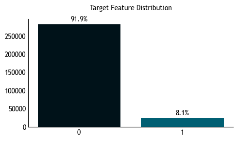

```python
fig, ax = plt.subplots(figsize=(5, 3))

create_countplot(
    df=df_clean,
    ax=ax,
    col="TARGET",
    colors=custom_palette,
    percent=1,
)

ax.set(title="Target Feature Distribution")

plt.tight_layout()
plt.show()
```

As defined, the target variable is as follows:

- 1: Client with payment difficulties - defined as having a late payment of more than X days on at least one of the first Y installments of the loan in our sample.
- 0: All other cases.

It is evident that the dataset is highly imbalanced, with approximately 92% of clients not experiencing payment troubles.

```python
df_copy = df_clean.copy()

numerical_cols = (
    df_copy.select_dtypes(include=["float", "int"])
    .drop("TARGET", axis=1)
    .columns.tolist()
)
corr_numerical_df = (
    df_copy[numerical_cols]
    .corrwith(df_copy["TARGET"])
    .reset_index()
    .rename(columns={0: "Correlation", "index": "Feature"})
)

categorical_cols = df_copy.select_dtypes(
    include=["category", "object"]
).columns.tolist()
corr_categorical = [
    (col, cramers_v(df[col], df_copy["TARGET"])) for col in categorical_cols
]
corr_categorical_df = pd.DataFrame(
    corr_categorical, columns=["Feature", "Correlation"]
).sort_values("Correlation", ascending=False)

corr_combined_df = pd.concat(
    [corr_numerical_df, corr_categorical_df], ignore_index=True
)

top_corr_df = pd.concat(
    [
        corr_combined_df[corr_combined_df["Correlation"] > 0].nlargest(
            10, "Correlation"
        ),
        corr_combined_df[corr_combined_df["Correlation"] < 0].nsmallest(
            10, "Correlation"
        ),
    ]
).sort_values("Correlation", ascending=False)
```

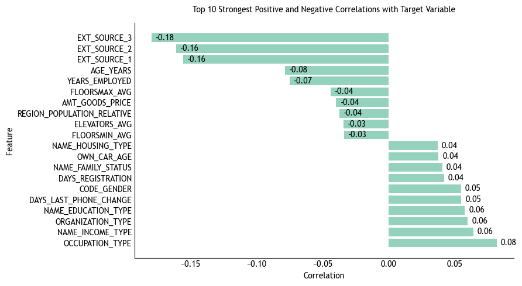

```python
fig, ax = plt.subplots(figsize=(9, 5))

create_barplot(
    df=top_corr_df,
    ax=ax,
    col="Feature",
    colors=custom_palette[3],
    plot_xlabel="Correlation",
    plot_ylabel="Feature",
    show_values=True,
)

ax.set_title("Top 10 Strongest Positive and Negative Correlations with Target Variable")
plt.tight_layout()
plt.show()
```

Due to the large number of features in the table, correlations with the target variable were calculated to identify which features should be further investigated.

Scores from external sources exhibit the strongest, albeit still weak, association with the target variable. Additionally, factors such as the client's age, years of employment, and occupation type also show some of the strongest correlations.

```python
df_encoded = pd.get_dummies(df_copy, columns=categorical_cols, drop_first=True)

df_encoded.columns = clean_feature_names(df_encoded.columns.tolist())
df_encoded.columns = (
    df_encoded.columns.str.replace("[^a-zA-Z0-9]", "_", regex=True)
    .str.replace("__", "_", regex=True)
    .str.strip()
)

y = df_encoded["TARGET"]
X = df_encoded.drop(columns=["TARGET"])
```

```python
X_train, X_test, y_train, y_test = train_test_split(X, y, test_size=0.2, random_state=1)
```

```python
model = lgb.LGBMClassifier(random_state=1, verbosity=-1)
model.fit(X_train, y_train)
```

```
LGBMClassifier(random_state=1, verbosity=-1)
```

```python
explainer = shap.TreeExplainer(model, feature_perturbation="tree_path_dependent")
shap_values = explainer.shap_values(X_test)
```

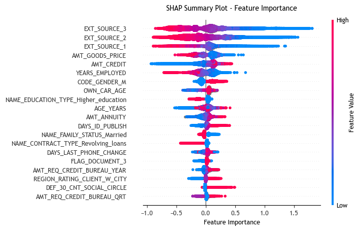

```python
shap.summary_plot(shap_values, X_test, show=False)

plt.gcf().set_size_inches(9, 4)

plt.gca().set_xlabel("Feature Importance", fontsize=9)
plt.title("SHAP Summary Plot - Feature Importance", fontsize=10)

for label in plt.gca().get_xticklabels() + plt.gca().get_yticklabels():
    label.set_fontsize(9)

cbar = plt.gcf().axes[1]
cbar.tick_params(labelsize=9)
cbar.set_ylabel("Feature Value", fontsize=9)

plt.show()
```

Another way to assess the potential importance of the features is through a SHAP summary plot.

This plot again indicates that scores from external sources are the most significant, with higher scores associated with a lower probability of the target value being true. Additionally, the price of the goods financed by the loan and the loan amount are also important features.

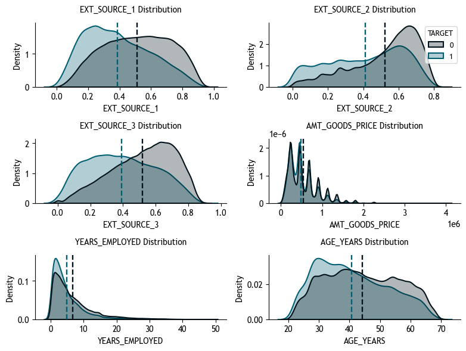

```python
features = [
    "EXT_SOURCE_1",
    "EXT_SOURCE_2",
    "EXT_SOURCE_3",
    "AMT_GOODS_PRICE",
    "YEARS_EMPLOYED",
    "AGE_YEARS",
]

fig, axes = plt.subplots(3, 2, figsize=(8, 6))
axes = axes.flatten()

for i, feature in enumerate(features):
    sns.kdeplot(
        x=df_encoded[feature],
        hue=df_encoded["TARGET"],
        fill=True,
        common_norm=False,
        palette=custom_palette[:2],
        alpha=0.3,
        linewidth=1.5,
        ax=axes[i],
        legend=(i == 1),
    )

    for target_value in [0, 1]:
        mean_value = df_encoded[df_encoded["TARGET"] == target_value][feature].mean()
        axes[i].axvline(
            mean_value,
            color=custom_palette[target_value],
            linestyle="--",
            linewidth=1.7,
        )

    axes[i].set_title(f"{feature} Distribution")
    sns.despine(ax=axes[i])

plt.tight_layout()
plt.show()
```

By plotting the KDE (Kernel Density Estimate) plots of the most important features, we can observe the most significant differences between the groups in the score features. Clients without payment problems tend to have higher mean scores. Additionally, it appears that longer employment duration and older age are associated with a lower probability of defaulting.

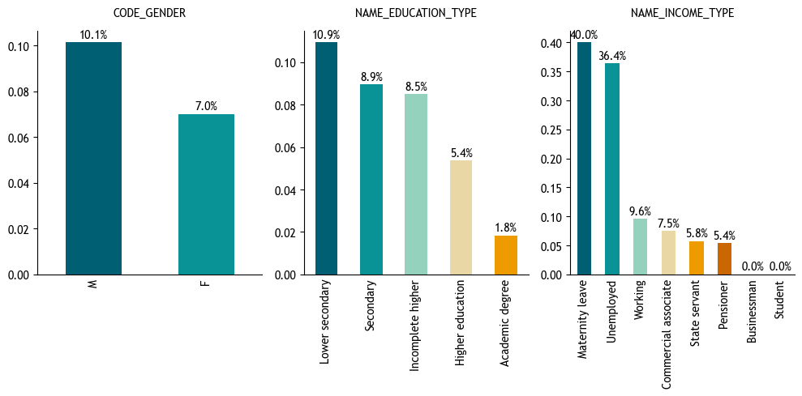

```python
cat_cols = [
    "CODE_GENDER",
    "NAME_EDUCATION_TYPE",
    "NAME_INCOME_TYPE",
]

plt.figure(figsize=(10, 5))
for i, col in enumerate(cat_cols, 1):
    plt.subplot(1, 3, i)
    create_proportion_barchart(df_clean, plt.gca(), col, "TARGET", plot_title=f"{col}")

plt.tight_layout()
plt.show()
```

Examining the categorical values, approximately 10% of males experienced difficulties repaying their loans, compared to only 7% of females. Regarding education, clients with lower secondary education faced the most challenges, while those with an academic degree had a significantly decreased likelihood of defaulting.

The most notable differences are observed in income sources, where 40% of clients on maternity leave and 36% of unemployed clients encountered repayment issues, while other income sources exhibited significantly lower percentages.

### Statistical Inference

Further, statistical inference will be performed.

**Target Population:** 307,511 clients of Home Credit.

**Significance Level**: The significance level (α) is chosen to be 0.05.

#### First Hypothesis

**Null Hypothesis (H0):** There is no difference in the distribution of age between individuals who defaulted and those who did not.

**Alternative Hypothesis (H1):** There is a difference in the distribution of age between individuals who defaulted and those who did not.

```python
age_default = df_clean.loc[df_clean["TARGET"] == 1, "AGE_YEARS"]
age_no_default = df_clean.loc[df_clean["TARGET"] == 0, "AGE_YEARS"]

stat_default, p_value_default = shapiro(age_default)
stat_no_default, p_value_no_default = shapiro(age_no_default)

print("Shapiro-Wilk Test for Age (Target = True):")
print(f"Test Statistic: {stat_default:.3f}, P-value: {p_value_default:.3f}")

print("\nShapiro-Wilk Test for Age (Target = False):")
print(f"Test Statistic: {stat_no_default:.3f}, P-value: {p_value_no_default:.3f}")
```

```
Shapiro-Wilk Test for Age (Target = True):
Test Statistic: 0.962, P-value: 0.000

Shapiro-Wilk Test for Age (Target = False):
Test Statistic: 0.970, P-value: 0.000
```

The Shapiro-Wilk tests for normality returned p-values of 0.000, suggesting significant deviations from normal distribution for both samples. Consequently, a non-parametric test will be employed to test the null hypothesis.

```python
statistic, p_value = stats.mannwhitneyu(age_default, age_no_default)

mean_default, lower_ci_default, upper_ci_default = calculate_confidence_interval(
    age_default
)

mean_no_default, lower_ci_no_default, upper_ci_no_default = (
    calculate_confidence_interval(age_no_default)
)

print(
    f"Mean Age for default: {mean_default:.2f}, Confidence Interval: ({lower_ci_default:.2f}, {upper_ci_default:.2f})"
)
print(
    f"Mean Age for no default: {mean_no_default:.2f}, Confidence Interval: ({lower_ci_no_default:.2f}, {upper_ci_no_default:.2f})"
)

statistic, p_value = stats.mannwhitneyu(age_default, age_no_default)

print(f"Mann-Whitney U Test: p-value = {p_value:.3f}")
```

```
Mean Age for default: 40.78, Confidence Interval: (40.64, 40.92)
Mean Age for no default: 44.21, Confidence Interval: (44.17, 44.26)
Mann-Whitney U Test: p-value = 0.000
```

The mean age of individuals who defaulted is 40.78 years (CI: 40.64–40.92), while for those who did not default, it is 44.21 years (CI: 44.17–44.26). The Mann-Whitney U test yields a p-value of 0.000, indicating a statistically significant difference in age between the two groups.

#### Second Hypothesis

**Null Hypothesis (H0):** There is no significant correlation between categorical independent variables and the dependent variable.

**Alternative Hypothesis (H1):** There is a significant correlation between categorical independent variables and the dependent variable.

```python
cat_hypothesis = [
    "NAME_CONTRACT_TYPE",
    "CODE_GENDER",
    "FLAG_OWN_CAR",
    "FLAG_OWN_REALTY",
    "NAME_TYPE_SUITE",
    "NAME_INCOME_TYPE",
    "NAME_EDUCATION_TYPE",
    "NAME_FAMILY_STATUS",
    "NAME_HOUSING_TYPE",
]
```

```python
alpha = 0.05
num_comparisons = len(cat_hypothesis) - 1
bonferroni_alpha = alpha / num_comparisons
bonferroni_alpha
```

```
0.00625
```

The significance level is set to be 0.05. Since multiple comparisons are going to be made, the significance level needs to be adjusted to account for the increased chance of Type I errors due to multiple tests.

Therefore, each test would need to have a p-value less than 0.00625 to be considered statistically significant.

```python
for col in cat_hypothesis:
    if col != "TARGET":
        contingency_table = pd.crosstab(df_clean["TARGET"], df_clean[col])
        chi2, p_value, _, _ = chi2_contingency(contingency_table)

        n = contingency_table.sum().sum()
        phi2 = chi2 / n
        min_dim = min(contingency_table.shape) - 1
        cramer_v = np.sqrt(phi2 / min_dim)

        print(f"Variable: {col}")
        print(f"Chi-square statistic: {chi2:.3f}")
        print(f"P-value: {p_value:.4f}")
        print(f"Cramer's V: {cramer_v:.3f}")
        print("\n")
```

```
Variable: NAME_CONTRACT_TYPE
Chi-square statistic: 293.151
P-value: 0.0000
Cramer's V: 0.031


Variable: CODE_GENDER
Chi-square statistic: 920.006
P-value: 0.0000
Cramer's V: 0.055


Variable: FLAG_OWN_CAR
Chi-square statistic: 146.656
P-value: 0.0000
Cramer's V: 0.022


Variable: FLAG_OWN_REALTY
Chi-square statistic: 11.576
P-value: 0.0007
Cramer's V: 0.006


Variable: NAME_TYPE_SUITE
Chi-square statistic: 32.825
P-value: 0.0000
Cramer's V: 0.010


Variable: NAME_INCOME_TYPE
Chi-square statistic: 1253.471
P-value: 0.0000
Cramer's V: 0.064


Variable: NAME_EDUCATION_TYPE
Chi-square statistic: 1019.213
P-value: 0.0000
Cramer's V: 0.058


Variable: NAME_FAMILY_STATUS
Chi-square statistic: 504.694
P-value: 0.0000
Cramer's V: 0.041


Variable: NAME_HOUSING_TYPE
Chi-square statistic: 420.556
P-value: 0.0000
Cramer's V: 0.037
```

The chi-square tests reveal statistically significant but generally weak associations between categorical variables and the likelihood of default. The strongest associations are observed for **income type** and **education type**, while most other variables show very weak associations. Overall, the effect sizes suggest that no single categorical variable has a dominant influence on default likelihood.

### Feature Engineering

Next, all tables will be merged into a single dataset, and new features will be created to uncover more interesting patterns.

Since the supplementary tables cannot be directly merged with the main table, most features will be derived by grouping the data by the current application ID.

Functions were created to calculate sums, means, maximum and minimum values, various financial ratios, differences, and new categorical values.

#### Application

```python
application = df_clean.copy()
calculate_application_features(application)
```

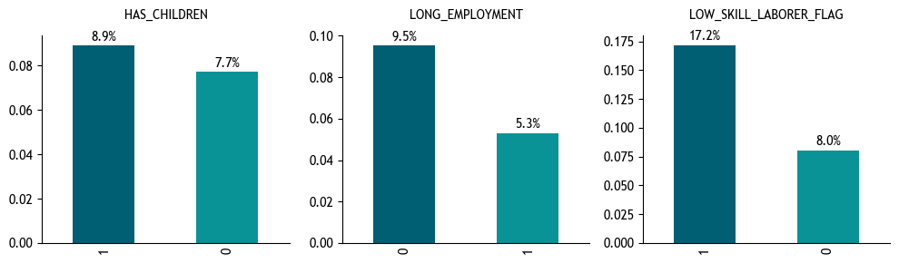

```python
cols_plot = [
    "HAS_CHILDREN",
    "LONG_EMPLOYMENT",
    "LOW_SKILL_LABORER_FLAG",
]

plt.figure(figsize=(10, 3))
for i, col in enumerate(cols_plot, 1):
    plt.subplot(1, 3, i)
    create_proportion_barchart(
        application,
        plt.gca(),
        col,
        "TARGET",
        plot_title=f"{col}",
    )

plt.tight_layout()
plt.show()
```

Visualizing a few of our newly created features reveals that individuals with children, those employed for a shorter duration, and low-skilled laborers exhibit an increased risk of being unable to repay their loans.

#### Bureau

```python
for col in ["DAYS_CREDIT_ENDDATE", "DAYS_CREDIT_UPDATE", "DAYS_ENDDATE_FACT"]:
    bureau[col].loc[bureau[col] < -40000] = np.nan

active_loans_agg = calculate_bureau_features(bureau, "Active")
closed_loans_agg = calculate_bureau_features(bureau, "Closed")

bureau_agg = pd.merge(
    active_loans_agg,
    closed_loans_agg,
    on="SK_ID_CURR",
    how="outer",
    suffixes=("_active", "_closed"),
)

gc.collect()
```

```
7784
```

#### POS Cash

```python
pos_cash_agg = calculate_poscash_features(pos_cash)

pos_cash_agg.reset_index(inplace=True)
```

#### Credit Card Balance

```python
cc_balance_agg = calculate_cc_balance_features(cc_balance)

cc_balance_agg.reset_index(inplace=True)
```

#### Installments

```python
installments_agg = calculate_installments_features(installments)

installments_agg.reset_index(inplace=True)
```

#### Previous Applications

```python
prev = previous_application.copy()

for f_ in [
    "DAYS_FIRST_DRAWING",
    "DAYS_FIRST_DUE",
    "DAYS_LAST_DUE_1ST_VERSION",
    "DAYS_LAST_DUE",
    "DAYS_TERMINATION",
]:
    prev[f_].loc[prev[f_] > 360000] = np.nan

prev_agg = calculate_prev_features(prev)
```

## Statistical Modeling

This section aims to develop a model that accurately predicts which clients are likely to experience difficulties in repaying their loans.

### Data Loading

```python
df_final = application
df_final = df_final.merge(bureau_agg, on="SK_ID_CURR", how="left")
df_final = df_final.merge(pos_cash_agg, on="SK_ID_CURR", how="left")
df_final = df_final.merge(cc_balance_agg, on="SK_ID_CURR", how="left")
df_final = df_final.merge(installments_agg, on="SK_ID_CURR", how="left")
df_final = df_final.merge(prev_agg, on="SK_ID_CURR", how="left")

df_final = downcast(df_final)
```

```python
del df
del bureau
del bureau_balance
del cc_balance
del installments
del pos_cash
del previous_application

gc.collect()
```

```
0
```

### Data Preparation

```python
df_final.drop(["SK_ID_CURR"], axis=1, inplace=True)
```

```python
X = df_final.drop("TARGET", axis=1)
y = df_final["TARGET"]

X_train, X_temp, y_train, y_temp = train_test_split(
    X, y, test_size=0.3, random_state=1, stratify=y
)
X_val, X_test, y_val, y_test = train_test_split(
    X_temp, y_temp, test_size=0.5, random_state=1, stratify=y_temp
)
```

The dataset is divided into training, validation, and test sets in a 70/15/15 split.

### Model Training and Evaluation

#### Dummy Classifier

To start, a dummy classifier is trained to establish a benchmark for comparing our other models.

```python
dummy_clf = DummyClassifier(strategy="stratified", random_state=1)

dummy_clf.fit(X_train, y_train)

y_pred = dummy_clf.predict(X_test)
y_pred_dummy = dummy_clf.predict_proba(X_test)[:, 1]

print("Classification Report:")
print(classification_report(y_test, y_pred_dummy))

auc = roc_auc_score(y_test, y_pred_dummy)
pr_auc = average_precision_score(y_test, y_pred_dummy)

print(f"ROC AUC Score: {auc:.3f}")
print(f"PR AUC Score: {pr_auc:.3f}")
```

```
Classification Report:
              precision    recall  f1-score   support

           0       0.92      0.92      0.92     42403
           1       0.09      0.09      0.09      3724

    accuracy                           0.85     46127
   macro avg       0.51      0.51      0.51     46127
weighted avg       0.85      0.85      0.85     46127

ROC AUC Score: 0.506
PR AUC Score: 0.082
```

The model has an accuracy of 0.85, but the macro average metrics suggest significant class imbalance, with the ROC AUC Score at 0.506 and the PR AUC Score at 0.082, indicating limited discriminative ability for the minority class.

#### Model Training

The LightGBM model was chosen due to its speed, efficiency, and flexibility. It handles large datasets effectively, mitigates overfitting, and supports categorical values, allowing us to spend less time on preprocessing and cleaning the data.

```python
lgb = LGBMClassifier(verbose=-1)
train_lgbm_model(lgb, X_train, y_train, X_val, y_val)
```

```
Base LGBM Train PR AUC Score: 0.3888
Base LGBM Validation PR AUC Score: 0.2663

Base LGBM Train AUC Score: 0.8400
Base LGBM Validation AUC Score: 0.7805
```

The performance metrics for the base LightGBM model indicate a notable discrepancy between training and validation results. The model struggles to generalize to unseen data, particularly in identifying positive instances.

While the LightGBM model shows improvement over the dummy classifier in terms of AUC scores, the relatively low PR AUC Score highlights significant room for enhancement in the model's ability to identify clients likely to default.

#### Model Tuning

To enhance the model's performance, few data transformations will be explored.

```python
feature_importance = pd.DataFrame(
    {"feature": X_train.columns, "importance": lgb.feature_importances_}
)

feature_importance = feature_importance.sort_values(by="importance", ascending=False)
```

##### Removing Low-Importance Features

```python
threshold = 0

low_importance_features = feature_importance[
    feature_importance["importance"] == threshold
]["feature"]

X_train_reduced = X_train.drop(columns=low_importance_features)
X_val_reduced = X_val.drop(columns=low_importance_features)
X_test_reduced = X_test.drop(columns=low_importance_features)

print(f"Removed {len(low_importance_features)} low-importance features")
```

```
Removed 50 low-importance features
```

```python
train_lgbm_model(lgb, X_train_reduced, y_train, X_val_reduced, y_val)
```

```
Base LGBM Train PR AUC Score: 0.3888
Base LGBM Validation PR AUC Score: 0.2663

Base LGBM Train AUC Score: 0.8400
Base LGBM Validation AUC Score: 0.7805
```

Features with an importance score of zero were identified and removed. 50 low-importance features were removed to simplify the model and potentially improve its performance.

Removing low-importance features did not change PR AUC and AUC scores. Nonetheless, it will improve the training time and the model will be easier to interpret.

##### Removing Highly Correlated Features

```python
cat_features = X_train_reduced.select_dtypes(
    include=["category", "object"]
).columns.tolist()

to_drop = remove_highly_correlated_features(X_train_reduced, cat_features)

X_train_corr = X_train_reduced.drop(columns=to_drop)
X_val_corr = X_val_reduced.drop(columns=to_drop)
X_test_corr = X_test_reduced.drop(columns=to_drop)
```

```
Number of highly correlated numerical features to be removed: 27
```

```python
train_lgbm_model(lgb, X_train_corr, y_train, X_val_corr, y_val)
```

```
Base LGBM Train PR AUC Score: 0.3878
Base LGBM Validation PR AUC Score: 0.2666

Base LGBM Train AUC Score: 0.8382
Base LGBM Validation AUC Score: 0.7798
```

Next, highly correlated features were identified and removed, resulting in 27 less features in the dataset.

The results were very similar, as performance metrics decreased minimally.

##### Encoding Features

```python
X_train_encoded, X_val_encoded, X_test_encoded = target_encode_auto(
    X_train_corr, X_val_corr, X_test_corr, y_train
)
```

```python
train_lgbm_model(lgb, X_train_encoded, y_train, X_val_encoded, y_val)
```

```
Base LGBM Train PR AUC Score: 0.3813
Base LGBM Validation PR AUC Score: 0.2692

Base LGBM Train AUC Score: 0.8357
Base LGBM Validation AUC Score: 0.7814
```

Although LightGBM can handle categorical features natively, target encoding was explored to enhance the model's performance.

While the train set metrics decreased slightly, the validation scores showed some improvement.

```python
X_train = X_train_encoded
X_val = X_val_encoded
X_test = X_test_encoded
```

##### Parameter Hypertuning

```python
optuna.logging.set_verbosity(optuna.logging.ERROR)
study = optuna.create_study(direction="maximize")
study.optimize(objective, n_trials=50)
```

```python
print("Best trial:")
trial = study.best_trial

print("Value: {:.4f}".format(trial.value))

print("Params: ")
for key, value in trial.params.items():
    print("    {}: {}".format(key, value))
```

```
Best trial:
Value: 0.1965
Params:
    num_leaves: 143
    min_child_samples: 85
    min_child_weight: 13
    colsample_bytree: 0.3940295666046615
    subsample: 0.8356181298320199
    max_depth: 7
    reg_lambda: 1.3285662838676373
    n_estimators: 2415
    reg_alpha: 1.3187649611391492
```

Next, Optuna study was set up to optimize a model's hyperparameters.

```python
best_params = {
    "num_leaves": 143,
    "min_child_samples": 85,
    "min_child_weight": 13,
    "colsample_bytree": 0.3940295666046615,
    "subsample": 0.8356181298320199,
    "max_depth": 7,
    "reg_lambda": 1.3285662838676373,
    "n_estimators": 2415,
    "reg_alpha": 1.3187649611391492,
}
```

```python
lgb_tuned = LGBMClassifier(verbose=0, learning_rate=0.01, **study.best_trial.params)

with open(os.devnull, "w") as fnull:
    with contextlib.redirect_stdout(fnull):
        lgb_tuned.fit(
            X_train,
            y_train,
            eval_set=[(X_val, y_val)],
            callbacks=[log_evaluation(period=100), early_stopping(30)],
        )
```

After identifying the best hyperparameter configuration, the learning rate was lowered to potentially improve the model's performance.

```python
cv_scores = cross_val_score(lgb_tuned, X_train, y_train, cv=5, scoring="roc_auc")
```

```python
print(f"Cross-Validation AUC Scores: {cv_scores}")
print(f"Mean AUC Score: {cv_scores.mean()}")
```

```
Cross-Validation AUC Scores: [0.78454569 0.78528378 0.79372123 0.78618617 0.78376659]
Mean AUC Score: 0.786700692708089
```

The cross-validation AUC scores demonstrate consistent performance across the five folds. The mean AUC score indicates a robust model with good discriminative ability in predicting outcomes.

```python
train_preds = lgb_tuned.predict_proba(X_train)[:, 1]
val_preds = lgb_tuned.predict_proba(X_val)[:, 1]
test_preds = lgb_tuned.predict_proba(X_test)[:, 1]

train_pr = average_precision_score(y_train, train_preds)
val_pr = average_precision_score(y_val, val_preds)
test_pr = average_precision_score(y_test, test_preds)

print("Tuned LGBM Train PR AUC:", train_pr)
print("Tuned LGBM Val PR AUC:", val_pr)
print("Tuned LGBM Test PR AUC:", test_pr)
```

```
Tuned LGBM Train PR AUC: 0.5735368278205527
Tuned LGBM Val PR AUC: 0.2865398565433192
Tuned LGBM Test PR AUC: 0.2910738377382279
```

The tuned LightGBM model shows significant improvement in the Train PR AUC. This indicates that the tuning process has enhanced the model's ability to predict positive cases in the training data.

However, the Validation PR AUC has increased to 0.2865, compared to 0.2692 from the base model. While this is an improvement, the validation performance still indicates potential overfitting, as the increase is modest relative to the improvement seen in the training set.

The Test PR AUC is reported at 0.2911, which is a slight increase from the validation score, suggesting that the model's performance is consistent across unseen data, but it remains relatively low.

```python
auc_score_val = roc_auc_score(y_val, val_preds)
auc_score_test = roc_auc_score(y_test, test_preds)

print(f"Validation AUC Score: {auc_score_val:.4f}")
print(f"Test AUC Score: {auc_score_test:.4f}")
```

```
Validation AUC Score: 0.7903
Test AUC Score: 0.7974
```

The tuned LightGBM model demonstrates a notable improvement in the Validation AUC Score.

Additionally, the Test AUC Score of 0.7974 reflects further improvement and suggests that the model generalizes well to unseen data. The increase in both validation and test scores signifies that the tuning efforts have not only optimized performance on the training data but have also positively impacted the model's predictive capability in real-world scenarios.

#### Model Evaluation

```python
final_pred = lgb_tuned.predict(X_test)

print(classification_report(y_test, final_pred))
```

```
              precision    recall  f1-score   support

           0       0.92      1.00      0.96     42403
           1       0.60      0.05      0.08      3724

    accuracy                           0.92     46127
   macro avg       0.76      0.52      0.52     46127
weighted avg       0.90      0.92      0.89     46127
```

The final model exhibits a high overall accuracy of 92%, indicating that it effectively classifies the majority of instances in the dataset.

However, for class 1 (clients with payment difficulties), the performance metrics are concerning. The precision is only 0.60, indicating that when the model predicts a client will default, it is correct 60% of the time. The recall is particularly low at 0.05, suggesting that the model only identifies 5% of the actual defaults, which can lead to many clients with payment difficulties being missed. The resulting F1-score for this class is merely 0.08, reflecting the significant challenges in predicting this outcome accurately.

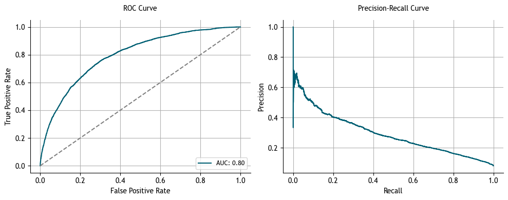

```python
plt.figure(figsize=(10, 4))

plt.subplot(1, 2, 1)
fpr, tpr, thresholds = roc_curve(y_test, test_preds)
plt.plot(fpr, tpr, color=custom_palette[1], label=f"AUC: {auc_score_test:.2f}")
plt.plot([0, 1], [0, 1], color="gray", linestyle="--")
plt.xlabel("False Positive Rate")
plt.ylabel("True Positive Rate")
plt.title("ROC Curve")
plt.legend(loc="lower right")
plt.grid(True)

plt.subplot(1, 2, 2)
prec, recall, _ = precision_recall_curve(y_test, test_preds)
plt.plot(recall, prec, color=custom_palette[1])
plt.xlabel("Recall")
plt.ylabel("Precision")
plt.title("Precision-Recall Curve")
plt.grid(True)

sns.despine()
plt.tight_layout()
plt.show()
```

```python
new_threshold = 0.08

y_pred_adj = (test_preds >= new_threshold).astype(int)

print("Classification Report for LightGBM with Updated Threshold:")
print(classification_report(y_test, y_pred_adj))
```

```
Classification Report for LightGBM with Updated Threshold:
              precision    recall  f1-score   support

           0       0.97      0.73      0.83     42403
           1       0.19      0.73      0.30      3724

    accuracy                           0.73     46127
   macro avg       0.58      0.73      0.56     46127
weighted avg       0.91      0.73      0.79     46127
```

Given the critical importance of reducing false negatives in this problem, the threshold for distinguishing between classes was adjusted to find a balance between precision and recall.

The overall accuracy of 73% reflects the trade-off between precision and recall. The model is better at identifying clients likely to default but suffers in precision for class 1 predictions. The macro average shows balanced recall but lower overall precision, while the weighted average indicates strong performance for non-defaulting clients.

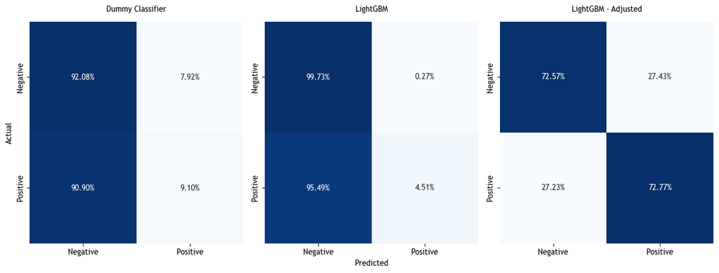

```python
plot_confusion_matrices(y_test, y_pred_dummy, final_pred, y_pred_adj)
```

The confusion matrices of the three built models - dummy classifier, LightGBM, and threshold-adjusted LightGBM - highlight their differences in performance:

- Dummy Classifier: This model misses most clients with repayment issues, leading to significant risk exposure. It struggles particularly with true positives, resulting in a high false negative rate.
- LightGBM: The unadjusted LightGBM model demonstrates exceptional performance in correctly identifying clients without payment difficulties, boasting extremely low false positives. However, it has an even higher false negative rate, indicating that it fails to identify many clients at risk of default.
- Threshold-Adjusted LightGBM: This model successfully reduces false negatives while still maintaining a reasonable true negative rate. The adjustments allow for better identification of clients with repayment difficulties, showcasing an improved balance between precision and recall.

To summarize, the model provides a valuable starting point for various tasks in the loan application process. It can quickly filter low-risk applicants and contribute to a broader risk assessment toolkit by offering insights for analysts evaluating loan applications.

Moreover, the model may uncover significant patterns related to defaults, which can inform policy or strategy even if not used for automated decision-making. It also identifies characteristics of customers less likely to default, benefiting marketing campaigns targeting promising prospects. For existing customers, the model can flag accounts needing proactive outreach to prevent defaults.

#### Observations

Moving on, we will analyze the feature importance.

```python
explainer = shap.TreeExplainer(lgb_tuned, feature_perturbation="tree_path_dependent")
shap_values = explainer.shap_values(X_test)
```

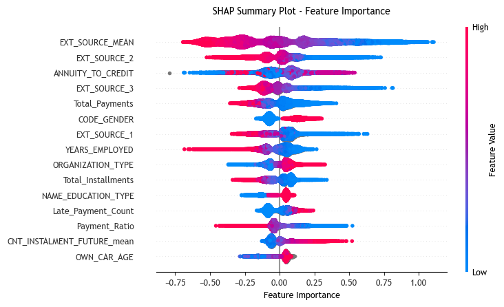

```python
shap.summary_plot(shap_values, X_test, max_display=15, show=False)

plt.gcf().set_size_inches(9, 4)

plt.gca().set_xlabel("Feature Importance", fontsize=9)
plt.title("SHAP Summary Plot - Feature Importance", fontsize=10)

for label in plt.gca().get_xticklabels() + plt.gca().get_yticklabels():
    label.set_fontsize(9)

cbar = plt.gcf().axes[1]
cbar.tick_params(labelsize=9)
cbar.set_ylabel("Feature Value", fontsize=9)

plt.show()
```

Plotting the feature importance shows that there is no single feature that stands out far above the rest. While the **mean external source score** and **annuity-to-credit ratio** are among the most important, the importance is spread across multiple features. This suggests that the model relies on a combination of different factors rather than heavily depending on any one feature for making predictions.

```python
shap_values = explainer(X_test)
```

```python
misclassified_index_fn = np.where((y_test == 1) & (test_preds < 0.05))[0][10]
misclassified_index_fp = np.where((y_test == 0) & (test_preds > 0.5))[0][10]
```

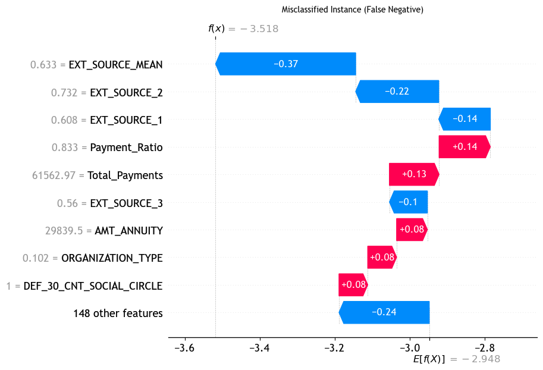

```python
plt.title("Misclassified Instance (False Negative)")
shap.plots.waterfall(shap_values[misclassified_index_fn])
```

Analyzing a SHAP waterfall chart for a false instances is beneficial as it helps understand why the model made an incorrect prediction.

For this false negative instance, external source scores were very influential. Scores had relatively high values, which the model associates with lower risk, pushing the prediction towards a false negative. This suggests that while these external scores are important in the model's decision-making process, they might overshadow other signals indicating the client could actually default.

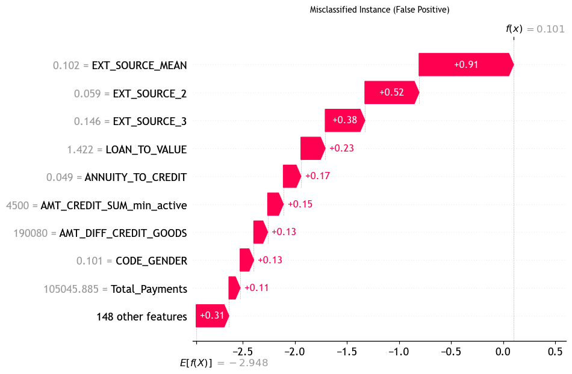

```python
plt.title("Misclassified Instance (False Positive)")
shap.plots.waterfall(shap_values[misclassified_index_fp])
```

Looking at the false positive case, the low external source scores contributed significantly to the model's decision to classify the client as high-risk.

This suggests that the model might be placing too much weight on external scores without enough consideration of other relevant factors. Also, the model might be overly sensitive to low values in these external source features.

## Summary and Recommendations

### Summary of the Findings

- **Target Variable Definition:** The target variable distinguishes clients with repayment difficulties from those without, with a highly imbalanced dataset (92% non-default).
- **KDE & Categorical Analysis:** KDE plots and categorical analysis showed that higher external scores, longer employment, and higher education levels correlated with lower default risks.
- **Feature Engineering:** Additional features were created using data from supplementary tables, focusing on financial ratios, sums, and categorical transformations.
- **LightGBM Choice:** LightGBM was selected for its efficiency with large datasets, ability to handle categorical features, and robust performance in preventing overfitting. Base LightGBM achieved a validation PR AUC score of 0.2663 and a validation AUC score of 0.7805.
- **Feature Selection:** Low-importance and highly correlated features were removed, resulting in a slight drop in PR AUC but more efficient model execution. Target encoding slightly increased the scores.
- **Hyperparameter Optimization:** Optuna was used to tune the model, yielding an increase in validation AUC (0.7903) and PR AUC (0.2865).
- **Threshold Adjustment:** The threshold was adjusted to reduce false negatives, significantly increasing recall (73%) but lowering precision.
- **Feature Importance & SHAP Analysis:** Engineered features like external scores and annuity/credit ratios were among the most important, with no single feature dominating. SHAP waterfall charts highlighted key features in false negative and false positive cases.

### Recommendations for Further Analysis

- Leverage all available tables: Integrate additional data sources to engineer more diverse and informative features, potentially improving model performance.
- Experiment with different models: Test a variety of machine learning algorithms to identify the best-performing model for predicting loan repayment difficulties.
- Explore feature aggregation methods and time series analysis: Aggregate features in different ways, such as by time windows or client history, and consider incorporating time series analysis for more dynamic insights.